# Plotly DASH pubilcation guide

13/07/2023

[figure not shown]

## What is Ploty DASH

Ploty DASH is a python package for creating dashboards. This guide will walk through how to publish a dashboard onto the Posit (Formerly RSConnect) server.

## Installing DASH and rsconnect

To install DASH:

```
pip install dash
```

You will also have to install “rsconnect” to publish the dashboard:

```
pip install rsconnect
```

To run rsconnect outwith it’s location:

```
set NEWPATH=C:\Users\XXXXXXXX\AppData\Roaming\Python\Python310\Scripts\
```

Replacing the X’s with your system username. This is usually your employee number.

Then:

```
set PATH=%PATH%;%NEWPATH%
```

## Creating a dashboard

This guide will not cover how to create a dashboard. More information can be found on the plotly dash website and courses can be found on Datacamp. You may want to try this with a simple dashboard first.

A simple hello world example:

```
from dash import Dash, html

app = Dash(__name__)

app.layout = html.Div([
    html.Div(children='Hello World')
])

if __name__ == '__main__':
    app.run(debug=True)
```

Save this as app.py

## API key

Log onto the Posit server with this link: https://dap-prd2-connect.azure.defra.cloud/

Enter your credentials.  
Click on your name and select API Keys from the menu bar that appears on the right hand side.

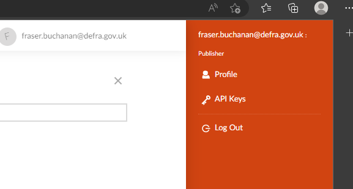

Click on “+ new api key”

[figure not shown]

Give it a name in the text box that pops up.

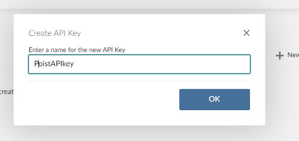

The second pop up gives you the chance to copy the 32 character alphanumeric code. Save this somewhere (for example in notepad) as you will require it later to publish and can be used for subsequent dashboards.

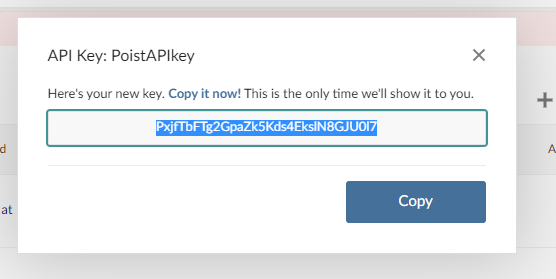

## Add API key to rsconnect

To configure the rsconnect package for the server:

```
rsconnect add   --server https://dap-prd2-connect.azure.defra.cloud/ --name \<name> --api-key XXXXXXXXXXXXXXXXXXXXXXXXXXXXXXX
```

Where <name> is of your choice of the dashboard name and the X’s are replaced with your own API key.

## Deploy Dashboard

Navigate to the folder that contains the folder that you dashboard files are located.

Then:

```
rsconnect deploy dash -n \<name> \<foldername>
```

Where <name> is replaced with the name you chose in the previous step, and <foldername> is the name of the folder containing you dashboard files.

## Viewing the dashboard on Posit

Return to the Posit server: https://dap-prd2-connect.azure.defra.cloud/

Click on “Content” on the left hand side. You should see your dashboard in the list named as you chose and your username under Author. Click on it and you will see your dashboard.

Please see tutorial on dashboard admin to apply settings to your dashboard.